# main

Erim Celen & Rafal

6/15/2021

# 1. Abstract

Time series surround us on all sides. Any phenomena that occurs at regular intervals and can be quantified is a series. Our pulse rate, power consumption or quotations of various financial instruments. Therefore, understanding and taming them is an extremely important task. In our work we would like to introduce you to a small piece of the world of time series and the incredible satisfaction that comes from getting to know them better.

On the given dataset, we extracted and tested the potential cointegration of the time series, which we explored through both data visualization and formal testing. Then, using VAR and ARIMA class models, we visualized the dependencies of the series and made predictions for the out-of-sample period. Finally, we compared accuracy of forecasts of prices using the ex-post forecast error measures and choose the winner model.

# 2. Aim of the study

The main purpose of our work is to provide a practical test of the skills learned during the semester of time series study and to familiarize ourselves with the analysis workflow used in real life.

# 3. Data Description

The data was generously provided as part of the project description and contain prices of ten financial instruments measured in daily intervals, for a total sample of 300 observations.

Head of Data

| date | y1 | y2 | y3 | y4 | y5 | y6 | y7 | y8 | y9 | y10 |
| --- | --- | --- | --- | --- | --- | --- | --- | --- | --- | --- |
| 2020-06-01 | 146.00 | 161.12 | 146.00 | 141.07 | 155.86 | 160.84 | 149.18 | 142.01 | 146.00 | 146.00 |
| 2020-06-02 | 146.00 | 161.10 | 146.00 | 141.08 | 156.00 | 160.89 | 143.44 | 139.39 | 146.00 | 146.00 |
| 2020-06-03 | 146.00 | 160.76 | 144.85 | 140.85 | 155.92 | 161.20 | 146.14 | 144.59 | 146.00 | 146.00 |
| 2020-06-04 | 147.29 | 159.86 | 143.73 | 141.32 | 158.61 | 161.01 | 148.73 | 144.92 | 146.00 | 146.08 |
| 2020-06-05 | 148.28 | 160.05 | 143.62 | 141.73 | 160.71 | 160.76 | 151.65 | 142.77 | 145.70 | 146.52 |
| 2020-06-06 | 150.86 | 160.53 | 144.82 | 138.68 | 165.80 | 160.14 | 152.19 | 141.82 | 144.37 | 144.56 |

# 4. Model building.

```r
cor(data[,-1]) %>% kable('simple')
```

|  | y1 | y2 | y3 | y4 | y5 | y6 | y7 | y8 | y9 | y10 |
| --- | --- | --- | --- | --- | --- | --- | --- | --- | --- | --- |
| y1 | 1.0000000 | 0.1273495 | 0.1282455 | 0.1616628 | 0.9999965 | -0.1608957 | 0.3686109 | 0.3550117 | -0.1599833 | 0.1612683 |
| y2 | 0.1273495 | 1.0000000 | 0.9999372 | 0.6040931 | 0.1274487 | 0.2075479 | 0.4456843 | 0.3436409 | 0.2081468 | 0.6044327 |
| y3 | 0.1282455 | 0.9999372 | 1.0000000 | 0.6040453 | 0.1283461 | 0.2071259 | 0.4452674 | 0.3435563 | 0.2077225 | 0.6043905 |
| y4 | 0.1616628 | 0.6040931 | 0.6040453 | 1.0000000 | 0.1616074 | 0.5861851 | 0.3807149 | -0.0112819 | 0.5881918 | 0.9999841 |
| y5 | 0.9999965 | 0.1274487 | 0.1283461 | 0.1616074 | 1.0000000 | -0.1608665 | 0.3685567 | 0.3549539 | -0.1599548 | 0.1612126 |
| y6 | -0.1608957 | 0.2075479 | 0.2071259 | 0.5861851 | -0.1608665 | 1.0000000 | 0.0440030 | -0.5598207 | 0.9996292 | 0.5856582 |
| y7 | 0.3686109 | 0.4456843 | 0.4452674 | 0.3807149 | 0.3685567 | 0.0440030 | 1.0000000 | 0.4339824 | 0.0452649 | 0.3809858 |
| y8 | 0.3550117 | 0.3436409 | 0.3435563 | -0.0112819 | 0.3549539 | -0.5598207 | 0.4339824 | 1.0000000 | -0.5614936 | -0.0108390 |
| y9 | -0.1599833 | 0.2081468 | 0.2077225 | 0.5881918 | -0.1599548 | 0.9996292 | 0.0452649 | -0.5614936 | 1.0000000 | 0.5876611 |
| y10 | 0.1612683 | 0.6044327 | 0.6043905 | 0.9999841 | 0.1612126 | 0.5856582 | 0.3809858 | -0.0108390 | 0.5876611 | 1.0000000 |

```r
data$date <- as.Date(data$date, format = "%Y-%m-%d")
data <- xts(data[, -1], order.by = data$date)
```

[output not shown]

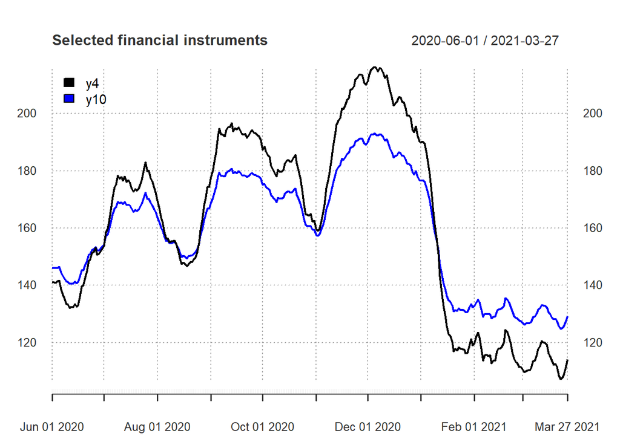

```r
plot(data[, c(4,10)],
     col = c("black", "blue"),
     major.ticks = "months",
     grid.ticks.on = "months",
     grid.ticks.lty = 3,
     main = "Selected financial instruments",
     legend.loc = "topleft")
```

```r
source("functions/testdf.R")
```

```r
y4_y10 <- data[,c(4,10)]
```

## Testing cointegration

### Checking the integration order with Augmented Dickey-Fuller test

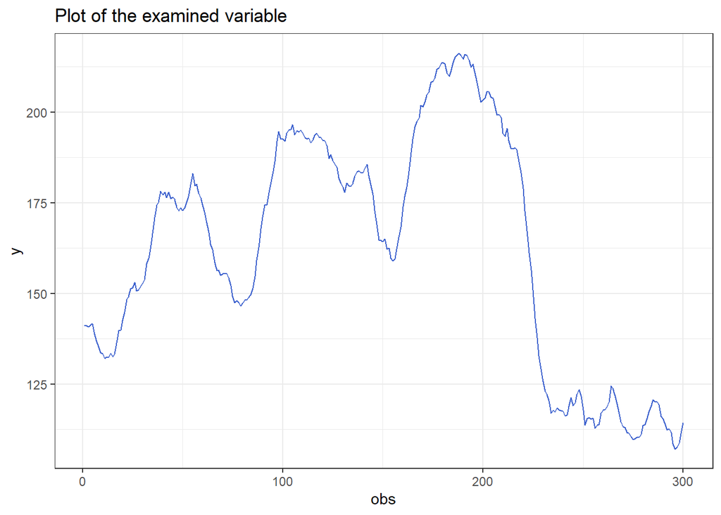

```r
resultsy4 <-
testdf(variable = y4_y10$y4,
       max.augmentations = 3)
```

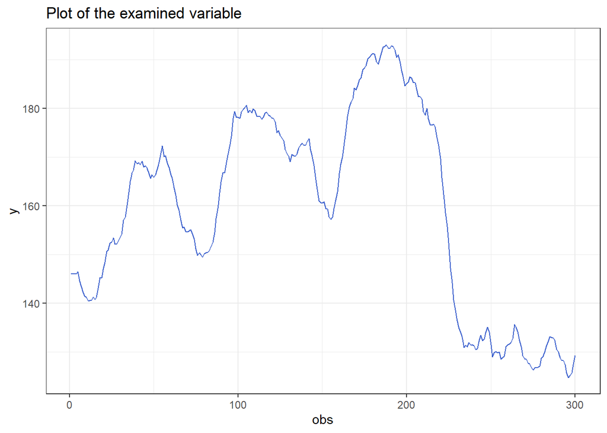

```r
resultsy10 <-
testdf(variable = y4_y10$y10,
       max.augmentations = 3)
```

```r
p_values <- cbind(resultsy10,resultsy4)
p_values <- p_values[,c(1,3,5,8,10)]
colnames(p_values) <- c("augmentations","p_adf_y10","p_bg_y10","p_adf_y4","p_bg_y4")

p_values %>%
  knitr::kable(digits = 3) %>%
  kableExtra::kable_styling(full_width = F,
                            bootstrap_options = c("striped"))
```

| augmentations | p_adf_y10 | p_bg_y10 | p_adf_y4 | p_bg_y4 |
| --- | --- | --- | --- | --- |
| 0 | 0.968 | 0.000 | 0.967 | 0.000 |
| 1 | 0.682 | 0.004 | 0.688 | 0.003 |
| 2 | 0.492 | 0.628 | 0.484 | 0.680 |
| 3 | 0.412 | 0.863 | 0.425 | 0.892 |

Both series examine non-stationary behavior. We will proceed by testing the first differences.

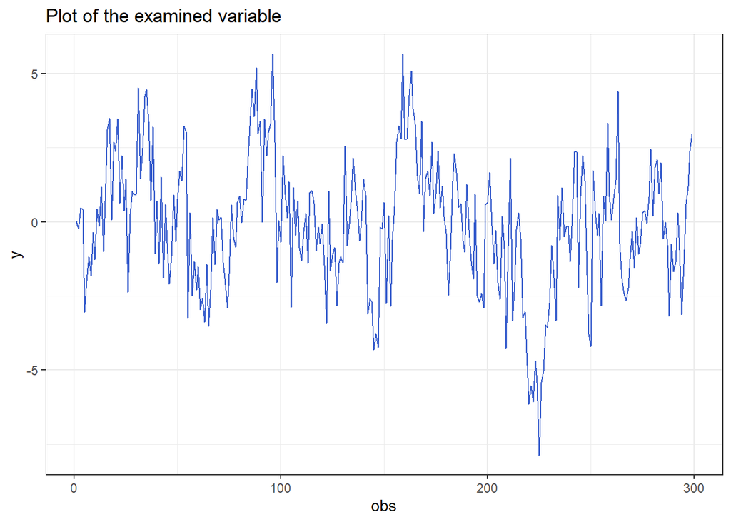

```r
results2y4 <-
testdf(variable = diff.xts(y4_y10$y4),
       max.augmentations = 3)
```

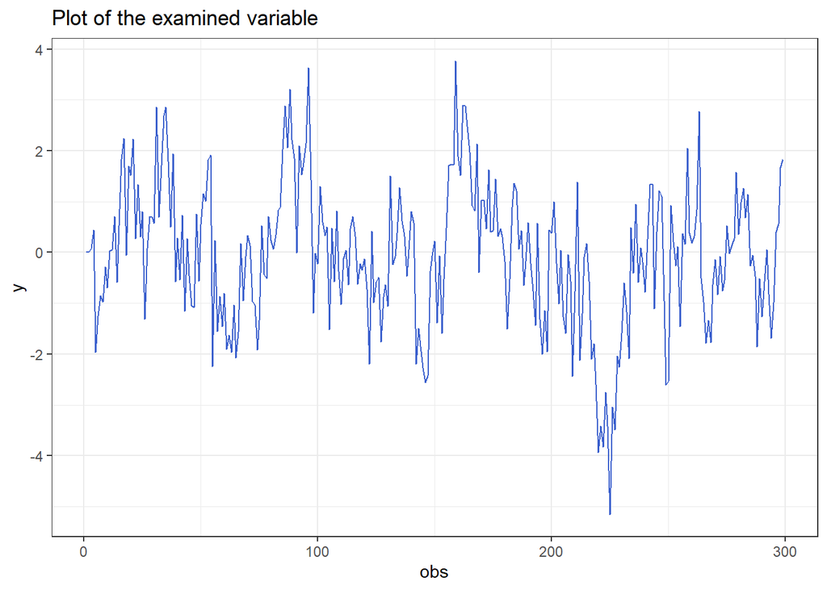

```r
results2y10 <-
testdf(variable = diff.xts(y4_y10$y10),
       max.augmentations = 3)
```

```r
p_values2 <- cbind(results2y10,results2y4)
p_values2 <- p_values2[,c(1,3,5,8,10)]
colnames(p_values2) <- c("augmentations","p_adf_y10","p_bg_y10","p_adf_y4","p_bg_y4")

p_values2 %>%
  knitr::kable(digits = 3) %>%
  kableExtra::kable_styling(full_width = F,
                            bootstrap_options = c("striped"))
```

| augmentations | p_adf_y10 | p_bg_y10 | p_adf_y4 | p_bg_y4 |
| --- | --- | --- | --- | --- |
| 0 | 0.01 | 0.005 | 0.01 | 0.003 |
| 1 | 0.01 | 0.676 | 0.01 | 0.730 |
| 2 | 0.01 | 0.895 | 0.01 | 0.920 |
| 3 | 0.01 | 0.941 | 0.01 | 0.982 |

With p-values lower than assumed 0.05, we can reject the null hypothesis that that a unit root is present in both time series. As a result, both variables are $\sim I(1)$, so in the next step we will check whether they are cointegrated.

Creating the in sample out sample.

```r
in_sample <- y4_y10[1:290]
out_of_sample <-y4_y10[291:nrow(y4_y10)]
```

## Cointegration test

```r
model.coint <- lm(y4 ~ y10, data = in_sample)
summary(model.coint)
```

```
##
## Call:
## lm(formula = y4 ~ y10, data = in_sample)
##
## Residuals:
##      Min       1Q   Median       3Q      Max
## -0.42992 -0.11959  0.01259  0.12050  0.57101
##
## Coefficients:
##                Estimate  Std. Error t value Pr(>|t|)
## (Intercept) -92.6546932   0.0886650   -1045   <2e-16 ***
## y10           1.6003601   0.0005487    2916   <2e-16 ***
## ---
## Signif. codes:  0 '***' 0.001 '**' 0.01 '*' 0.05 '.' 0.1 ' ' 1
##
## Residual standard error: 0.1852 on 288 degrees of freedom
## Multiple R-squared:      1,  Adjusted R-squared:      1
## F-statistic: 8.506e+06 on 1 and 288 DF,  p-value: < 2.2e-16
```

# The cointregration vector and its equation.

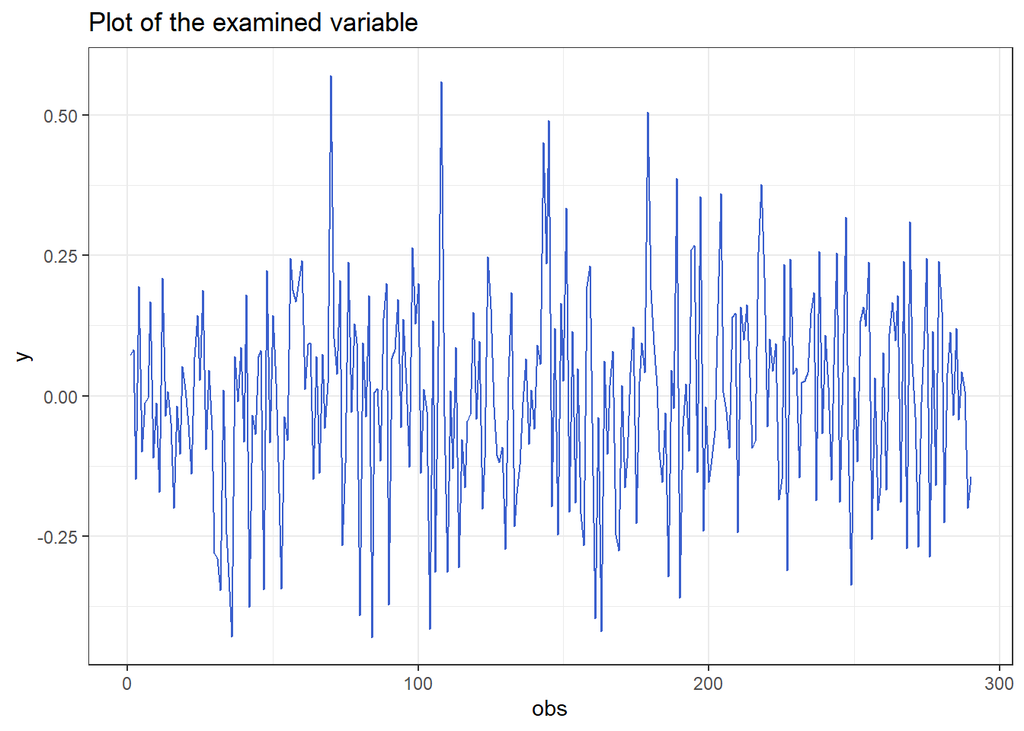

```
##   augmentations        adf p_adf     bgodfrey      p_bg
## 1             0 -17.768741  0.01 0.0053069528 0.9419264
## 2             1 -11.003054  0.01 0.0087833022 0.9253322
## 3             2  -9.541974  0.01 0.0002760301 0.9867444
## 4             3  -8.665776  0.01 0.0003746381 0.9845575
```

```r
#Adf test for residuals.
testdf(variable = residuals(model.coint), max.augmentations = 3)
```

Using ADF test with no augmentation, we can reject the null hypothseis about non-stationarity of residuals, so residuals are stationary, which means that series *y_4* and *y_10* are cointegrated.

Next we proceed to test whether *y_4* Granger causes *y_10* and vice versa.

## Causality test

```r
grangertest(y4 ~ y10,
            data = y4_y10,
            order = 3)
```

```
## Granger causality test
##
## Model 1: y4 ~ Lags(y4, 1:3) + Lags(y10, 1:3)
## Model 2: y4 ~ Lags(y4, 1:3)
##   Res.Df Df      F     Pr(>F)
## 1    290
## 2    293 -3 9.9679 0.00000284 ***
## ---
## Signif. codes:  0 '***' 0.001 '**' 0.01 '*' 0.05 '.' 0.1 ' ' 1
```

```r
grangertest(y10 ~ y4,
            data = y4_y10,
            order = 3)
```

```
## Granger causality test
##
## Model 1: y10 ~ Lags(y10, 1:3) + Lags(y4, 1:3)
## Model 2: y10 ~ Lags(y10, 1:3)
##   Res.Df Df      F    Pr(>F)
## 1    290
## 2    293 -3 5.9916 0.0005657 ***
## ---
## Signif. codes:  0 '***' 0.001 '**' 0.01 '*' 0.05 '.' 0.1 ' ' 1
```

At 1% significance level we observe bi-directional feedback.

## VAR Model

Since we observed bi-directional causality we can try to estimate a VAR model. To find the proper order of VAR model we will use information criteria.

```r
VARselect(y4_y10, lag.max = 6, season = 12) %>%
  .$criteria %>%
  t() %>%
  as_tibble() %>%
  mutate(nLags = 1:nrow(.)) %>%
  kbl(digits = 3) %>%
  kable_classic("striped", full_width = F)
```

| AIC(n) | HQ(n) | SC(n) | FPE(n) | nLags |
| --- | --- | --- | --- | --- |
| -2.626 | -2.486 | -2.275 | 0.072 | 1 |
| -3.165 | -3.005 | -2.764 | 0.042 | 2 |
| -3.259 | -3.078 | -2.808 | 0.038 | 3 |
| -3.248 | -3.047 | -2.746 | 0.039 | 4 |
| -3.230 | -3.009 | -2.679 | 0.040 | 5 |
| -3.215 | -2.974 | -2.613 | 0.040 | 6 |

Information criteria are the lowest for the 3rd lag. As a result, let’s estimate the model with 3 lags and seasonal dummies.

```r
varseason <- VAR(y4_y10,
                    p = 3,
                    season = 12)

summary(varseason)
```

```
##
## VAR Estimation Results:
## =========================
## Endogenous variables: y4, y10
## Deterministic variables: const
## Sample size: 297
## Log Likelihood: -323.006
## Roots of the characteristic polynomial:
## 0.981 0.8244 0.4763 0.3042 0.3042 0.2758
## Call:
## VAR(y = y4_y10, p = 3, season = 12L)
##
##
## Estimation results for equation y4:
## ===================================
## y4 = y4.l1 + y10.l1 + y4.l2 + y10.l2 + y4.l3 + y10.l3 + const + sd1 + sd2 + sd3 + sd4 + sd5 + sd6 + sd7 + sd8 + sd9 + sd10 + sd11
##
##         Estimate Std. Error t value    Pr(>|t|)
## y4.l1    -0.7788     0.5215  -1.493     0.13648
## y10.l1    3.5076     0.8305   4.223 0.000032613 ***
## y4.l2    -1.4386     0.5244  -2.743     0.00647 **
## y10.l2    2.0751     0.8578   2.419     0.01619 *
## y4.l3    -1.6259     0.5311  -3.061     0.00242 **
## y10.l3    2.1607     0.8562   2.524     0.01217 *
## const  -447.5632    87.9037  -5.092 0.000000654 ***
## sd1      -0.5203     0.4594  -1.133     0.25838
## sd2      -1.3448     0.4612  -2.916     0.00383 **
## sd3      -0.9934     0.4627  -2.147     0.03268 *
## sd4      -0.2514     0.4542  -0.553     0.58044
## sd5      -0.4959     0.4555  -1.089     0.27727
## sd6      -0.9169     0.4548  -2.016     0.04475 *
## sd7      -0.6175     0.4591  -1.345     0.17971
## sd8      -0.7690     0.4566  -1.684     0.09326 .
## sd9      -0.7471     0.4596  -1.625     0.10519
## sd10     -1.3854     0.4559  -3.039     0.00260 **
## sd11     -0.7972     0.4586  -1.738     0.08325 .
## ---
## Signif. codes:  0 '***' 0.001 '**' 0.01 '*' 0.05 '.' 0.1 ' ' 1
##
##
```

[output cut: 32 more lines]

```
## Residual standard error: 1.008 on 279 degrees of freedom
## Multiple R-Squared: 0.9977,  Adjusted R-squared: 0.9976
## F-statistic:  7162 on 17 and 279 DF,  p-value: < 2.2e-16
##
##
##
## Covariance matrix of residuals:
##        y4   y10
## y4  2.571 1.606
## y10 1.606 1.017
##
## Correlation matrix of residuals:
##         y4    y10
## y4  1.0000 0.9934
## y10 0.9934 1.0000
```

We can notice that indeed, few selected seasonal dummies are statistically significant.

### VAR model diagnostics

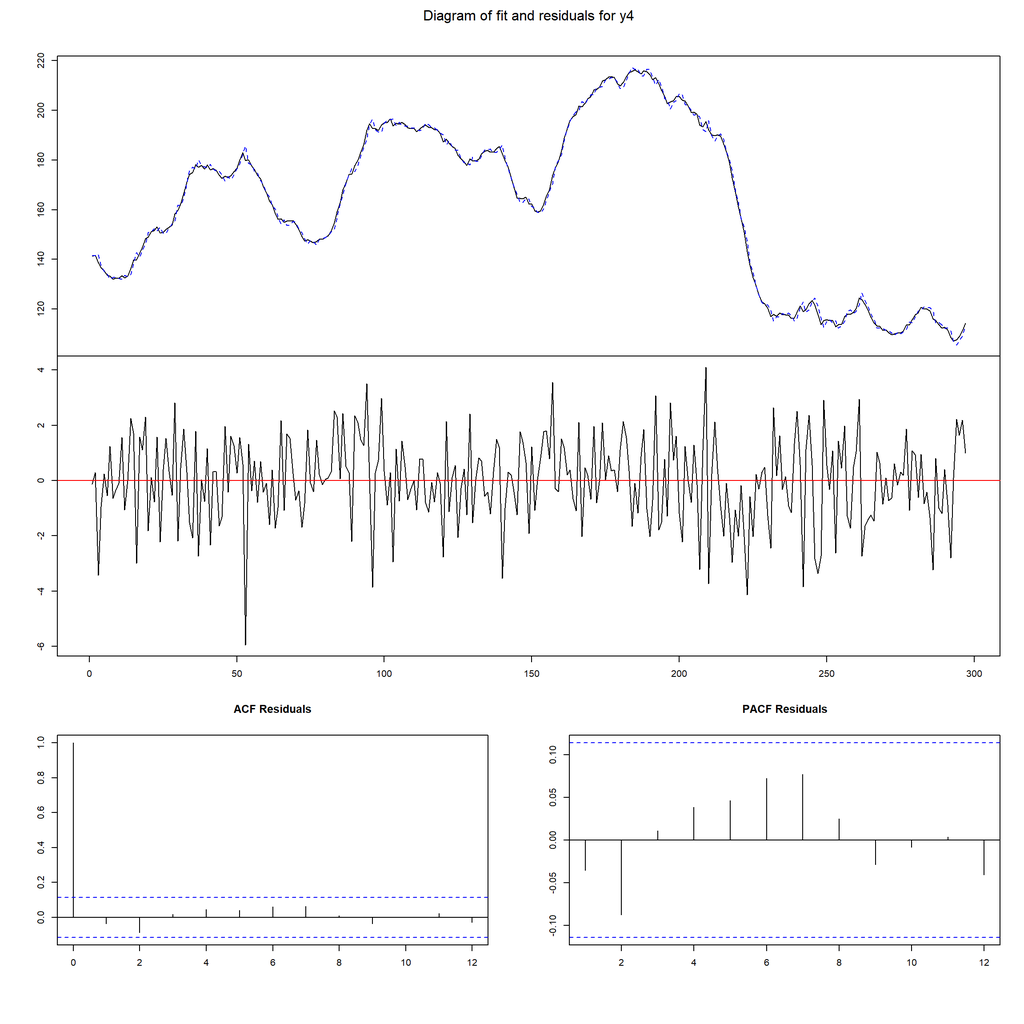

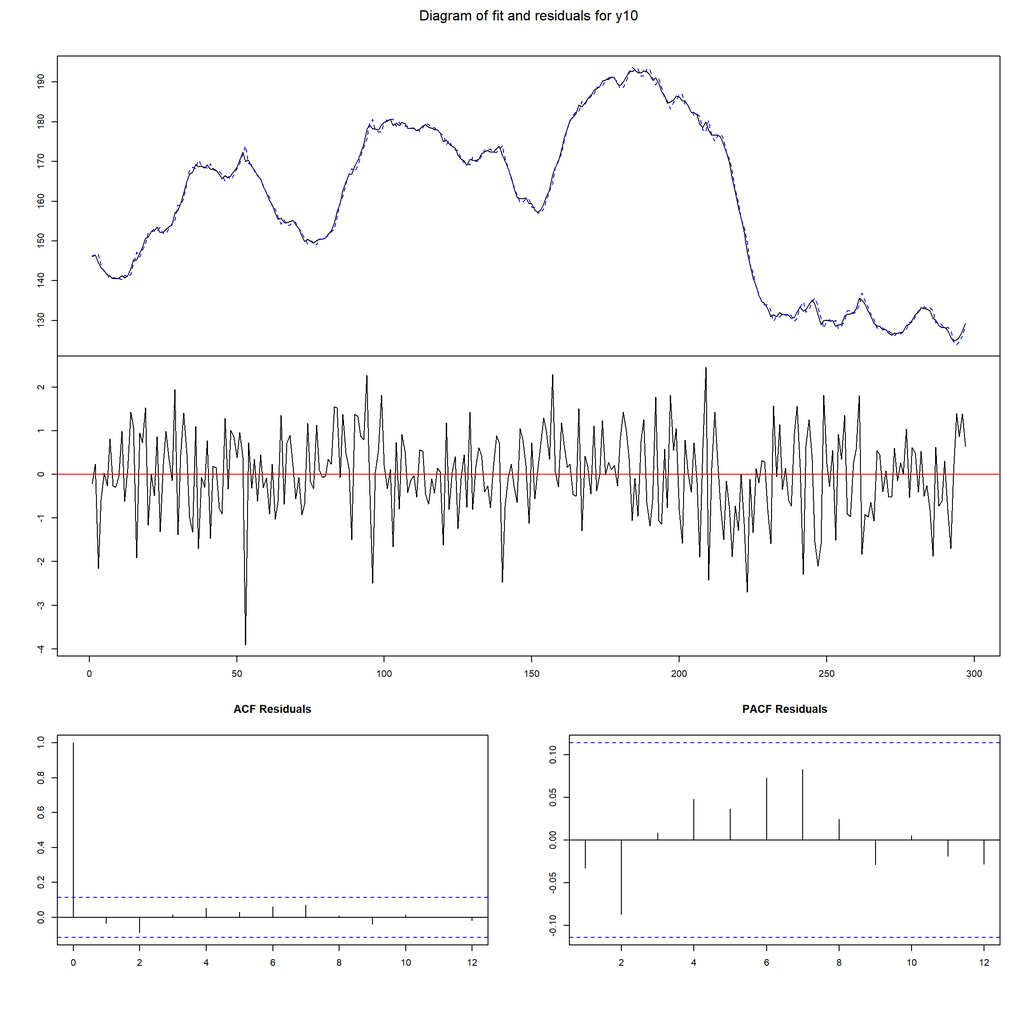

```r
plot(varseason)
```

After visual inspection we can conclude, that no further lags are statistically significant. In the next step let’s verify this formally using the Breusch-Godfrey (BG) test.

```r
serial.test(varseason, type = "BG")
```

```
##
##  Breusch-Godfrey LM test
##
## data:  Residuals of VAR object varseason
## Chi-squared = 20.784, df = 20, p-value = 0.41
```

We can not reject the null hypothesis about the lack of autocorellation among residuals. There is no need to extend our model by adding further lags.

### Forecasting with VAR

```r
y4_y10.short <- VAR(in_sample,
                    p = 3,
                    season = 12)
```

Now, let’s and run the forecasts:

```r
y4_y10.forecast <- predict(y4_y10.short,
                                 n.ahead = 10,
                                 ci = 0.95) # 95% confidence interval
```

VAR forecasts for y_4:

```r
y4_y10.forecast$fcst$y4
```

```
##           fcst     lower    upper        CI
##  [1,] 114.7144 111.57332 117.8555  3.141068
##  [2,] 115.4428 109.99070 120.8950  5.452145
##  [3,] 116.2076 108.07376 124.3414  8.133829
##  [4,] 116.7307 105.79808 127.6634 10.932647
##  [5,] 117.8088 104.06163 131.5560 13.747185
##  [6,] 118.6763 102.16463 135.1880 16.511692
##  [7,] 119.7221 100.53955 138.9047 19.182592
##  [8,] 119.9508  98.20751 141.6941 21.743274
##  [9,] 120.4721  96.29034 144.6540 24.181806
## [10,] 121.5337  95.03833 148.0292 26.495409
```

VAR forecasts for y_10:

```r
y4_y10.forecast$fcst$y10
```

```
##           fcst    lower    upper        CI
##  [1,] 129.5625 127.5864 131.5387  1.976156
##  [2,] 130.0431 126.6151 133.4711  3.427957
##  [3,] 130.5018 125.4001 135.6034  5.101605
##  [4,] 130.9010 124.0529 137.7492  6.848130
##  [5,] 131.5152 122.9087 140.1217  8.606491
##  [6,] 132.1000 121.7670 142.4331 10.333080
##  [7,] 132.7036 120.7022 144.7050 12.001387
##  [8,] 132.8555 119.2549 146.4561 13.600575
##  [9,] 133.1492 118.0256 148.2727 15.123503
## [10,] 133.8095 117.2412 150.3778 16.568334
```

```r
y4_forecast <- xts(y4_y10.forecast$fcst$y4[,-4],
                    # we exclude the last column with CI
                    tail(index(y4_y10), 10))

names(y4_forecast) <- c("y4_fore", "y4_lower", "y4_upper")

y10_forecast <- xts(y4_y10.forecast$fcst$y10[,-4],
                    # we exclude the last column with CI
                    tail(index(y4_y10), 10))

names(y10_forecast) <- c("y10_fore", "y10_lower", "y10_upper")


y4_y10_forecast <- merge(y4_y10,
                 y4_forecast,
                 y10_forecast)
```

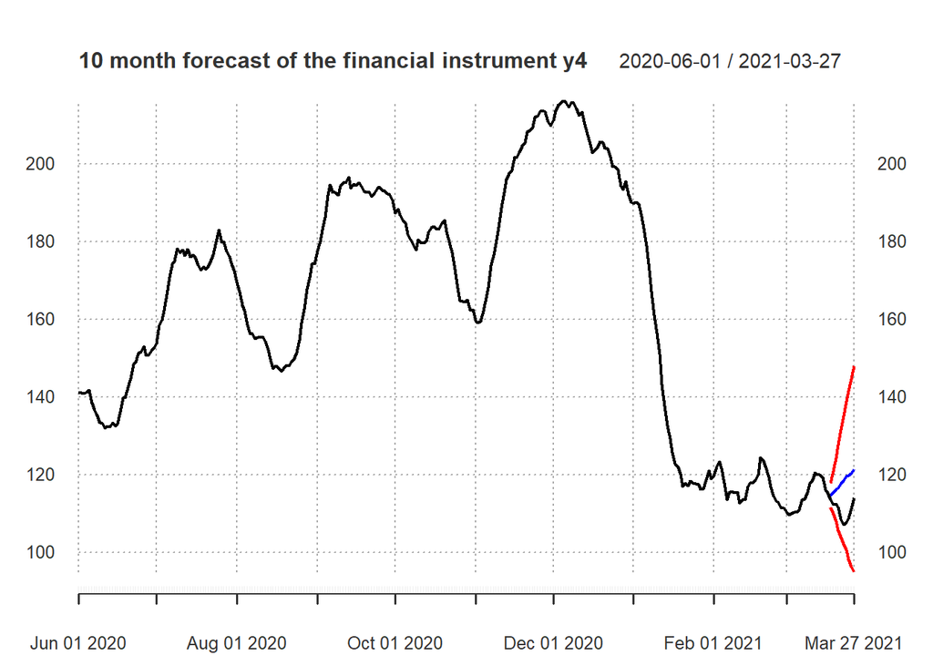

```r
plot(y4_y10_forecast[, c("y4", "y4_fore","y4_lower", "y4_upper")],
     major.ticks = "months",
     grid.ticks.on = "months",
     grid.ticks.lty = 3,
     main = "10 month forecast of the financial instrument y4",
     col = c("black", "blue", "red", "red"))
```

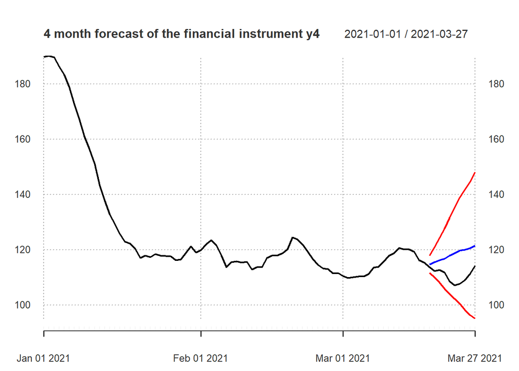

```r
plot(y4_y10_forecast["2021/", c("y4", "y4_fore",
                 "y4_lower", "y4_upper")],
     major.ticks = "months",
     grid.ticks.on = "months",
     grid.ticks.lty = 3,
     main = "4 month forecast of the financial instrument y4",
     col = c("black", "blue", "red", "red"))
```

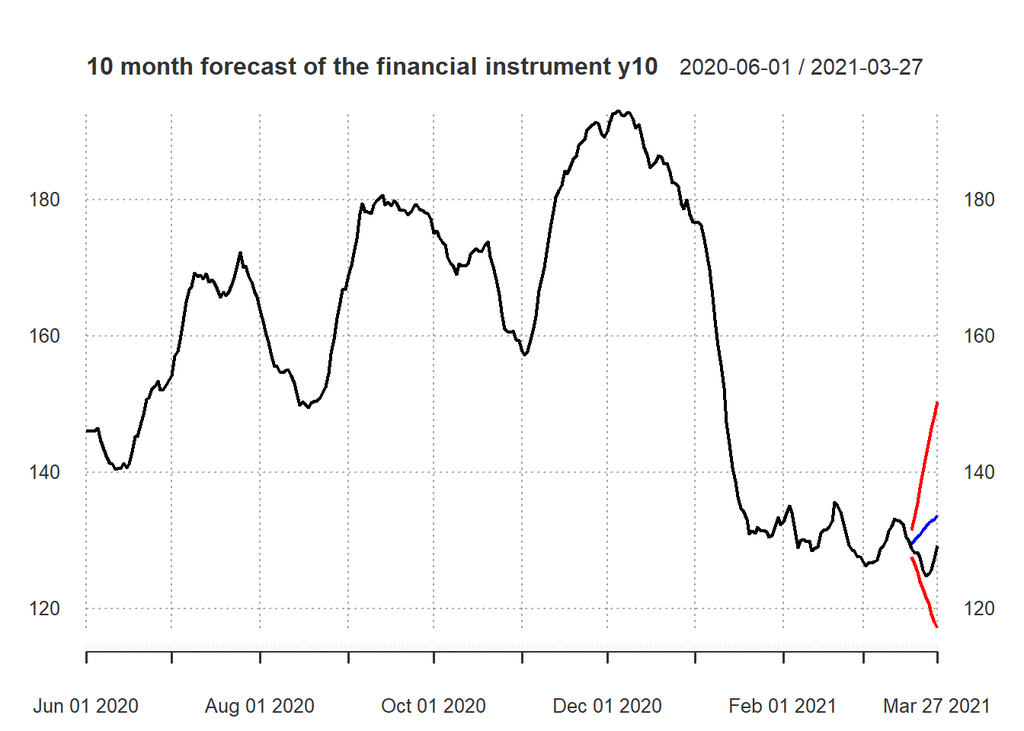

```r
plot(y4_y10_forecast[, c("y10", "y10_fore",
                 "y10_lower", "y10_upper")],
     major.ticks = "months",
     grid.ticks.on = "months",
     grid.ticks.lty = 3,
     main = "10 month forecast of the financial instrument y10",
     col = c("black", "blue", "red", "red"))
```

### Forecast accuracy measures

```r
y4_y10_forecast$mae.y4   <-  abs(y4_y10_forecast$y4 - y4_y10_forecast$y4_fore)
y4_y10_forecast$mse.y4   <-  (y4_y10_forecast$y4 - y4_y10_forecast$y4_fore) ^ 2
y4_y10_forecast$mape.y4  <-  abs((y4_y10_forecast$y4 - y4_y10_forecast$y4_fore)/y4_y10_forecast$y4)
y4_y10_forecast$amape.y4 <-  abs((y4_y10_forecast$y4 - y4_y10_forecast$y4_fore) /
                            (y4_y10_forecast$y4 + y4_y10_forecast$y4_fore))

y4_y10_forecast$mae.y10   <-  abs(y4_y10_forecast$y10 - y4_y10_forecast$y10_fore)
y4_y10_forecast$mse.y10   <-  (y4_y10_forecast$y10 - y4_y10_forecast$y10_fore) ^ 2
y4_y10_forecast$mape.y10  <-  abs((y4_y10_forecast$y10 - y4_y10_forecast$y10_fore)/y4_y10_forecast$y10)
y4_y10_forecast$amape.y10 <-  abs((y4_y10_forecast$y10 - y4_y10_forecast$y10_fore) /
                            (y4_y10_forecast$y10 + y4_y10_forecast$y10_fore))
```

Finally, we can calculate its averages:

```r
colMeans(y4_y10_forecast[, 9:16], na.rm = TRUE)
```

```
##      mae.y4      mse.y4     mape.y4    amape.y4     mae.y10     mse.y10
##  7.32295072 67.39277611  0.06673024  0.03201355  4.61113822 26.67567240
##    mape.y10   amape.y10
##  0.03646601  0.01782376
```

Although the level of change was captured by our model, unfortunately its direction is projected inversely.

## ARIMA Model

As a starting point, we will use auto arima algorithm for searching optimal parameters, utilizing the `arima.best.AIC` function.

```r
arima.best.AIC <-
  auto.arima(y4_y10$y4,
             d = 1,             # parameter d of ARIMA model
             max.p = 6,         # Maximum value of p
             max.q = 6,         # Maximum value of q
             max.order = 12,    # maximum p+q
             start.p = 1,       # Starting value of p in stepwise procedure
             start.q = 1,       # Starting value of q in stepwise procedure
             ic = "aic",        # Information criterion to be used in model selection.
             stepwise = FALSE,  # if FALSE considers all models
             allowdrift = TRUE, # include a constant
             trace = TRUE)      # show summary of all models considered
```

```
##
##  Fitting models using approximations to speed things up...
##
##  ARIMA(0,1,0)                    : 1332.908
##  ARIMA(0,1,0) with drift         : 1334.43
##  ARIMA(0,1,1)                    : 1249.605
##  ARIMA(0,1,1) with drift         : 1251.314
##  ARIMA(0,1,2)                    : 1207.736
##  ARIMA(0,1,2) with drift         : 1209.545
##  ARIMA(0,1,3)                    : 1196.682
##  ARIMA(0,1,3) with drift         : 1198.517
##  ARIMA(0,1,4)                    : 1185.007
##  ARIMA(0,1,4) with drift         : 1186.906
##  ARIMA(0,1,5)                    : 1179.772
##  ARIMA(0,1,5) with drift         : 1181.709
##  ARIMA(0,1,6)                    : 1178.276
##  ARIMA(0,1,6) with drift         : 1180.23
##  ARIMA(1,1,0)                    : 1185.489
##  ARIMA(1,1,0) with drift         : 1187.418
##  ARIMA(1,1,1)                    : 1162.621
##  ARIMA(1,1,1) with drift         : 1164.611
##  ARIMA(1,1,2)                    : 1164.373
##  ARIMA(1,1,2) with drift         : 1166.363
##  ARIMA(1,1,3)                    : 1166.357
##  ARIMA(1,1,3) with drift         : 1168.347
##  ARIMA(1,1,4)                    : 1166.947
##  ARIMA(1,1,4) with drift         : 1168.934
##  ARIMA(1,1,5)                    : 1168.738
##  ARIMA(1,1,5) with drift         : 1170.724
##  ARIMA(1,1,6)                    : 1170.143
##  ARIMA(1,1,6) with drift         : 1172.125
##  ARIMA(2,1,0)                    : 1165.944
##  ARIMA(2,1,0) with drift         : 1167.923
##  ARIMA(2,1,1)                    : 1165.36
##  ARIMA(2,1,1) with drift         : 1167.351
##  ARIMA(2,1,2)                    : 1167.067
##  ARIMA(2,1,2) with drift         : 1169.057
##  ARIMA(2,1,3)                    : 1169.028
##  ARIMA(2,1,3) with drift         : 1171.018
##  ARIMA(2,1,4)                    : 1166.837
```

[output cut: 53 more lines]

```
##  ARIMA(6,1,3)                    : 1172.638
##  ARIMA(6,1,3) with drift         : 1174.66
##  ARIMA(6,1,4)                    : 1168.356
##  ARIMA(6,1,4) with drift         : 1170.314
##  ARIMA(6,1,5)                    : Inf
##  ARIMA(6,1,5) with drift         : Inf
##  ARIMA(6,1,6)                    : Inf
##  ARIMA(6,1,6) with drift         : Inf
##
##  Now re-fitting the best model(s) without approximations...
##
##
##
##
##  Best model: ARIMA(1,1,1)
```

The AIC criterion is lowest for the model: ARIMA(1,1,1)

```r
coeftest(arima.best.AIC)
```

```
##
## z test of coefficients:
##
##      Estimate Std. Error z value       Pr(>|z|)
## ar1  0.866586   0.039582 21.8936      < 2.2e-16 ***
## ma1 -0.422484   0.070477 -5.9946 0.000000002039 ***
## ---
## Signif. codes:  0 '***' 0.001 '**' 0.01 '*' 0.05 '.' 0.1 ' ' 1
```

```r
Box.test(resid(arima.best.AIC), type = "Ljung-Box", lag =  1)
```

```
##
##  Box-Ljung test
##
## data:  resid(arima.best.AIC)
## X-squared = 0.029981, df = 1, p-value = 0.8625
```

We can not reject the null hypothesis, about data being independently distributed.

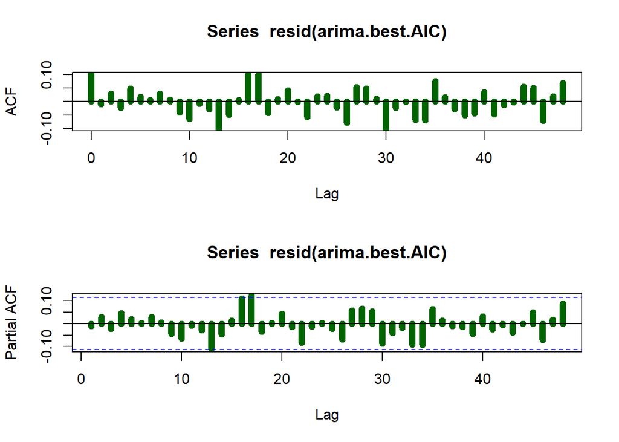

```r
par(mfrow = c(2, 1))
acf(resid(arima.best.AIC),
    lag.max = 48,
    lwd = 7,
    col = "dark green",
    na.action = na.pass,
    ylim = c(-0.1, 0.1))
pacf(resid(arima.best.AIC),
     lag.max = 48,
     lwd = 7,
     col = "dark green",
     na.action = na.pass)
```

### Forecast

```r
forecasts <- forecast(arima.best.AIC, # model for prediction
                      h = 10) # how many periods outside the sample
```

```r
forecasts_data <- data.frame(f_mean  = as.numeric(forecasts$mean),
                             f_lower = as.numeric(forecasts$lower[, 2]),
                             f_upper = as.numeric(forecasts$upper[, 2]))

forecasts_data <- xts(forecasts_data,tail(index(y4_y10), 10))

names(forecasts_data) <- c("y4_mean", "y4_lower", "y4_upper")

y4_y10_forecast_arima <- merge(y4_y10,forecasts_data)
```

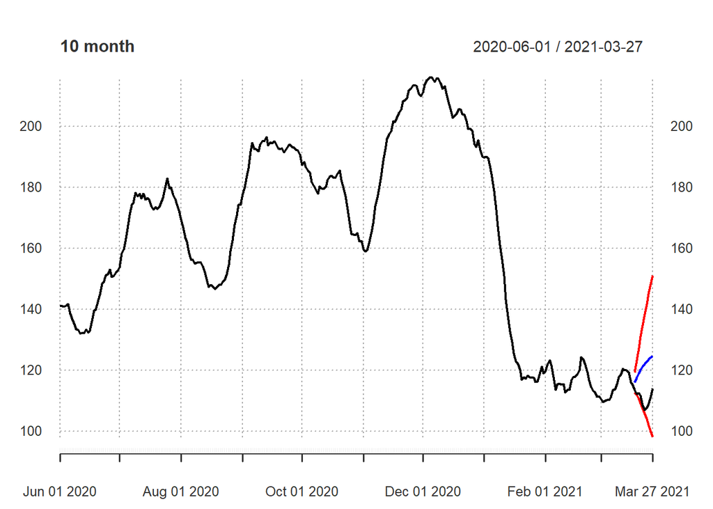

```r
plot(y4_y10_forecast_arima[, c("y4", "y4_mean","y4_lower", "y4_upper")],
     major.ticks = "months",
     grid.ticks.on = "months",
     grid.ticks.lty = 3,
     main = "10 month",
     col = c("black", "blue", "red", "red"))
```

```r
y4_y10_forecast_arima$mae   <-  abs(y4_y10_forecast_arima$y4 - y4_y10_forecast_arima$y4_mean)
y4_y10_forecast_arima$mse   <-  (y4_y10_forecast_arima$y4 - y4_y10_forecast_arima$y4_mean) ^ 2
y4_y10_forecast_arima$mape  <-  abs((y4_y10_forecast_arima$y4 - y4_y10_forecast_arima$y4_mean)/y4_y10_forecast_arima$y4)
y4_y10_forecast_arima$amape <-  abs((y4_y10_forecast_arima$y4 - y4_y10_forecast_arima$y4_mean)/(y4_y10_forecast_arima$y4 + y4_y10_forecast_arima$y4_mean))
```

```r
colMeans(y4_y10_forecast_arima[, c("mae", "mse", "mape", "amape")], na.rm = TRUE)
```

```
##          mae          mse         mape        amape
##  10.37744744 126.14560500   0.09438873   0.04470941
```

# 5. Results

Similar to VAR model, although the level of change was captured by our model, unfortunately its direction is projected inversely. Looking at the accuracy measures, VAR model was characterized by lower mae and mse, hence this would be our best fitted model for this time series.